# PEC2 -Distribución normal, Intervalos de Confianza, Regresión y Contrastes de Hipótesis

## 4.1 **Analisis de residuos**

- La variabilidad que se muestra en residuos en los vehiculos con precio bajo se muestra constante a lo largo del eje X. Sin embargo tiene un patrón muy poco cónico lo que indica falta de homogeneidad en la varianza. A pesar de eso se evidencia que la mayoria de los puntos estas muy cercanos a la recta.
- La condición de normalidad no se satisface, posiblemente por los outliers, se muestra al final de la grafica (Normal Q-Q) unos puntos por encima de la recta de regresión

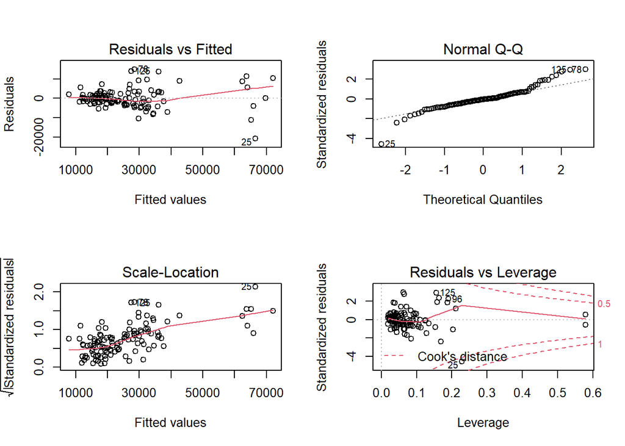

```r
par(mfrow = c(2, 2))
plot(mylm1)
```

**Se plantean las siguientes hipotesis:** Hipotesis nula: $H_{0}: \beta_i =0$ Hipotesis bilateral: $H_{0}: \beta_i\neq0$

```r
anova( mylm, mylm1)
```

```
## Analysis of Variance Table
##
## Model 1: Precio ~ Caballos + Ancho + Longitud + PesoBruto + Grupo + Deposito_litro +
##     Consumo_litro
## Model 2: Precio ~ Caballos + Ancho + Longitud + PesoBruto + Grupo + Consumo_litro
##   Res.Df        RSS Df Sum of Sq     F Pr(>F)
## 1    106 2833915441
## 2    107 2856559760 -1 -22644319 0.847 0.3595
```

En este caso (p-value = 0.3595), la hipótesis nula de que el coeficiente de regresión del predictor Deposito_litro es igual a cero no puede ser rechazada. El predictor Deposito_litro no contribuye al modelo.